# Modul 08 - Simple Linear Regression

### Visualasi hasil data testing

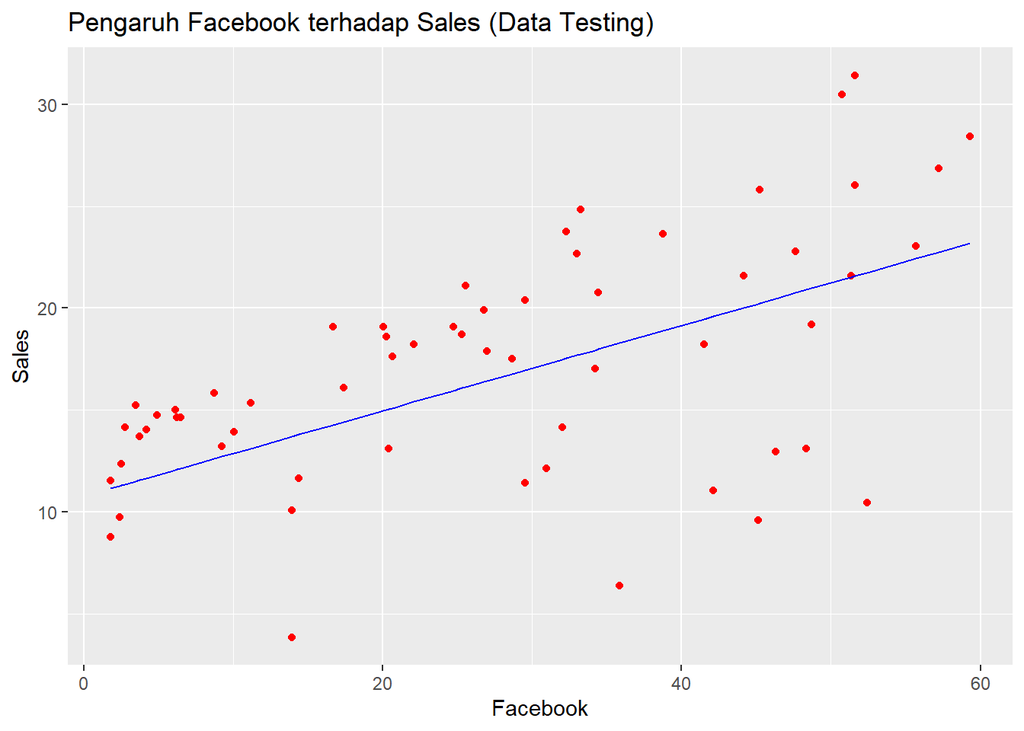

```r
ggplot() + geom_point(aes(x = testingset$facebook,
                          y = testingset$sales), colour = 'red') +
  geom_line(aes(x = testingset$facebook,
                y = predict(lm.r, newdata = testingset)), colour = 'blue') +
  ggtitle('Pengaruh Facebook terhadap Sales (Data Testing)') +
  xlab('Facebook') +
  ylab('Sales')
```

### Evaluasi

**Sum of Squared Errors (SSE)** adalah metrik evaluasi yang mengukur jumlah kuadrat dari selisih antara nilai prediksi dari model regresi dan nilai aktual dalam data. SSE dapat memberikan gambaran tentang seberapa baik model sesuai dengan data.

Dalam konteks regresi linear sederhana, SSE dihitung dengan menjumlahkan kuadrat dari selisih antara nilai prediksi $\hat{Y_i}$ dan nilai aktual $Y_i$ untuk setiap observasi:

$$SSE = \sum_{i=1}^{n} (Y_i -
\hat{Y_i})^2$$

Dalam R, Anda dapat mengakses SSE langsung dari objek model regresi menggunakan fungsi `sum(model$residuals^2)`. Semakin kecil nilai SSE, semakin baik modelnya, karena SSE mencerminkan seberapa baik model dapat memperkirakan nilai aktual dalam dataset. Namun, penggunaan SSE sebaiknya selalu dikombinasikan dengan metrik evaluasi lainnya, seperti R-squared, MSE, atau uji lainnya, untuk mendapatkan gambaran yang lengkap tentang kinerja model.

```r
# Menghitung SSE
sse_f <- sum(lm.r$residuals^2)
cat("Sum of Squared Errors (SSE):", sse_f, "\n")
```

```
## Sum of Squared Errors (SSE): 3802.062
```

**R-Squared**, Nilai R-squared mengindikasikan seberapa besar variasi dalam variabel terikat yang dapat dijelaskan oleh model. Nilai R-squared berkisar antara 0 (model tidak menjelaskan variasi sama sekali) hingga 1 (model menjelaskan seluruh variasi). Anda dapat menghitung R-squared (koefisien determinasi) dari model regresi linear sederhana menggunakan fungsi `summary()` pada objek model

```r
# Mengitung R-Square
model.summary <- summary(lm.r)
r_squared_f <- model.summary$r.squared
cat("R-squared:", r_squared_f, "\n")
```

```
## R-squared: 0.3423927
```

**Mean Squared Error (MSE)** Menghitung MSE dapat memberikan gambaran tentang seberapa baik model dapat menjelaskan variasi dalam data. Semakin rendah MSE dan semakin tinggi $R^2$, semakin baik modelnya.

```r
# Menghitung MSE
mse <- mean(lm.r$residuals^2)
cat("Mean Squared Error (MSE):", mse, "\n")
```

```
## Mean Squared Error (MSE): 27.15758
```

Metode evaluasi ini memberikan pandangan holistik tentang kinerja model regresi linear sederhana, dan pemilihan metode yang sesuai tergantung pada kebutuhan spesifik analisis Anda.